# LAL+ Final Project--Prediction of Default Payment Next Month

**Presentation Slide Link:** https://docs.google.com/presentation/d/15OpVcGe3ug_jb9cFCcbB05E87pB_Z-6SFVpAAaXbKxU/edit?usp=sharing

#### Information, including context and description of the data:

“Back to 2005, the credit card issuers in Taiwan faced the cash and credit card debt crisis and the delinquency is expected to peak in the third quarter of 2006 (Chou, 2006). In order to increase market share, card-issuing banks in Taiwan over-issued cash and credit cards to unqualified applicants. At the same time, most cardholders, irrespective of their repayment ability, overused credit card for consumption and accumulated heavy credit and cash– card debts. The crisis caused the blow to consumer finance confidence and it is a big challenge for both banks and cardholders.” (Cheng,2009).

In most developed countries, credit card is one of the major consumer lending products. In United States, credit card including roughly 30% of total consumer lending (USD 3.6 tn in 2016) and it about USD $3.3 billion in Taiwan. There are some differences that in credit card charge off levels between banks. To provide a significant business opportunity for banks, it is important to be able to predict which clients are most probable to default. When we say someone default on his debt or loan, which means he fail to repay a loan according to the terms agreed to in the promissory note. And as the lender may begin adding fees and increasing rate. If the lender considers a debt in default, the loan may be turned over to a collection agency. This results in financial losses to the bank as well as the damage to the credit rating of the clients. Thus, it is an important problem to be solved.

Description of the data:  
The data sets contains 25 varibales and 30000 observations in total.

- Response variable: default payment next month (Yes = 1, No = 0)
- ID: A unique Id field which represents a customer.

Explain Response variable:  
From the perspective of risk management, credit card clients are generally divided into two groups: creditable clients or not creditable clients. Whether a client with/without default payment is the key to divide the group. For creditable clients, they are less probable to default and pay off their credit card monthly in time. For not creditable clients, they are more probable to default and have a high probability of make a late payment, which can decrease their credit level. The datasets set a binary variable, default payment next month (Yes = 1, No = 0), to indicate whether the client is default.

Explain predictors:  
To study which predictors are significant related to clients’ probability to default and how these predictors related to the clients’ probability to default, the data was collected with 23 variables as predictors, and each column represent a predictor:  
23 predictors

- LIMIT_BAL: Credit line, which is amount of the given credit (NT dollar): it includes both the individual consumer credit and his/her family (supplementary) credit.
- SEX: Gender (1 = male; 2 = female).
- EDUCATION: Education (1 = graduate school; 2 = university; 3 = high school; 4 = others).
- MARRIAGE: Marital status (1 = married; 2 = single; 3 = others).
- AGE: Age (year).
- PAY_0 - PAY_6: History of past payment records (from April to September, 2005)  
  `The measurement scale for the repayment status: (-1 = pay duly; 1 = payment delay for one month; 2 = payment delay for two months; . . .; 8 = payment delay for eight months; 9 = payment delay for nine months and above)`
- PAY_0 = the repayment status in September, 2005;
- PAY_2 = the repayment status in August, 2005;
- PAY_3 = the repayment status in July, 2005;
- PAY_4 = the repayment status in June, 2005;
- PAY_5 = the repayment status in May, 2005;
- PAY_6 = the repayment status in April, 2005.
- BILL_AMT1 - BILL_AMT6: Amount in bill statement (NT dollar).
- BILL_AMT1 = amount of bill statement in September, 2005;
- BILL_AMT2 = amount of bill statement in August, 2005;
- BILL_AMT3 = amount of bill statement in July, 2005;
- BILL_AMT4 = amount of bill statement in June, 2005;
- BILL_AMT5 = amount of bill statement in May, 2005;
- BILL_AMT6 = amount of bill statement in April, 2005.
- PAY_AMT1 - PAY_AMT6: Amount of previous payment (NT dollar).
- PAY_AMT1 = amount paid in September, 2005;
- PAY_AMT2 = amount paid in August, 2005;
- PAY_AMT3 = amount paid in July, 2005;
- PAY_AMT4 = amount paid in June, 2005;
- PAY_AMT5 = amount paid in May, 2005;
- PAY_AMT6 = amount paid in April, 2005.

Explain observations:  
In this dataset, each row is an observational unit: One row represent for one clients. The 30000 observations means the dataset collect 30000 different clients in total, and we use different ID for each row to indicate each clients.

How the data is collected:  
The data set is originally from a Taiwanese bank, collected form October 2005. The bank has gathered data on 30000 clients. It includes information about default payments, demographic factors ,credit data, history of payment and bill statement of credit card clients in Taiwan from April 2005 to September 2005. The original dataset can be found at UCI Machine Learning Repository.

Common knowledge:  
We pay off our credit card monthly with a minimum amount of money. There always has a due date that you have to pay off the money you borrowed (or at least the minimum amount) by that deadline. If we fail to pay off, it comes to loan delinquency, at the time the bank can charge us a “late fee”. Extended delinquency can result a loan default. The consequences of you loan and any interest you owe becomes immediately due can result into that you can no longer receive deferment or forbearance, and you lose eligibility for other benefits, such as the ability to choose a repayment plan.

Reference：  
I-Cheng Yeh , Che-hui Lien.(2009) The comparisons of data mining techniques for the predictive accuracy of probability of default of credit card clients. ScienceDirect.  
Chou, M. (2006). Cash and credit card crisis in Taiwan. Business Weekly, 24–27.

**Import the necessary packages**

```python
import numpy as np
import pandas as pd
from sklearn import datasets
import random
import seaborn as sns
import matplotlib.pyplot as plt
from sklearn.metrics import accuracy_score
```

**1. Load the data**

```python
data=pd.read_excel("default of credit card clients.xls",header=1)
print (data.shape)
```

```
(30000, 25)
```

- The dataset has 30000 obervations and 25 variables.
- We start by looking to the data features (default by first 5 rows).

```python
data.head()
```

|  | ID | LIMIT_BAL | SEX | EDUCATION | MARRIAGE | AGE | PAY_0 | PAY_2 | PAY_3 | PAY_4 | ... | BILL_AMT4 | BILL_AMT5 | BILL_AMT6 | PAY_AMT1 | PAY_AMT2 | PAY_AMT3 | PAY_AMT4 | PAY_AMT5 | PAY_AMT6 | default payment next month |
| --- | --- | --- | --- | --- | --- | --- | --- | --- | --- | --- | --- | --- | --- | --- | --- | --- | --- | --- | --- | --- | --- |
| 0 | 1 | 20000 | 2 | 2 | 1 | 24 | 2 | 2 | -1 | -1 | ... | 0 | 0 | 0 | 0 | 689 | 0 | 0 | 0 | 0 | 1 |
| 1 | 2 | 120000 | 2 | 2 | 2 | 26 | -1 | 2 | 0 | 0 | ... | 3272 | 3455 | 3261 | 0 | 1000 | 1000 | 1000 | 0 | 2000 | 1 |
| 2 | 3 | 90000 | 2 | 2 | 2 | 34 | 0 | 0 | 0 | 0 | ... | 14331 | 14948 | 15549 | 1518 | 1500 | 1000 | 1000 | 1000 | 5000 | 0 |
| 3 | 4 | 50000 | 2 | 2 | 1 | 37 | 0 | 0 | 0 | 0 | ... | 28314 | 28959 | 29547 | 2000 | 2019 | 1200 | 1100 | 1069 | 1000 | 0 |
| 4 | 5 | 50000 | 1 | 2 | 1 | 57 | -1 | 0 | -1 | 0 | ... | 20940 | 19146 | 19131 | 2000 | 36681 | 10000 | 9000 | 689 | 679 | 0 |

5 rows × 25 columns

###### Checking missing values in variables.

```python
data.isnull().sum()
```

```
ID                            0
LIMIT_BAL                     0
SEX                           0
EDUCATION                     0
MARRIAGE                      0
AGE                           0
PAY_0                         0
PAY_2                         0
PAY_3                         0
PAY_4                         0
PAY_5                         0
PAY_6                         0
BILL_AMT1                     0
BILL_AMT2                     0
BILL_AMT3                     0
BILL_AMT4                     0
BILL_AMT5                     0
BILL_AMT6                     0
PAY_AMT1                      0
PAY_AMT2                      0
PAY_AMT3                      0
PAY_AMT4                      0
PAY_AMT5                      0
PAY_AMT6                      0
default payment next month    0
dtype: int64
```

- Based on the data description and table shows above, there is no missing or nan values in our data set.

We notice that our describe MARRIAGE only have 3 categoricals and EDUCATION have 6 categoricals, so that we decide changed those non meaning categorical to knownn.

```python
data.MARRIAGE=data["MARRIAGE"].replace(0,3)
print(data["MARRIAGE"].value_counts())
data.EDUCATION=data["EDUCATION"].replace(5,4)
data.EDUCATION=data["EDUCATION"].replace(6,4)
print(data["EDUCATION"].value_counts())
```

[output not shown]

**2. Distinguish categorical and continuous variables**

We want to distinguish categorical and continuous variables. When unique value in a variable greater than 15, we consider as continuous variables otherwise we consider as categorical variable. Seperating continuous and categorical variables will help us to summary statistics better.

```python
cat_v = []
con_v = []
for c in data.columns:
    if len(data[c].value_counts().index)<=15:
        cat_v.append(c)
    else:
        con_v.append(c)
```

```python
print("The continuous variables: ", con_v, "\n")
print("The categorical variables: ", cat_v,"\n")
print("There are ",len(con_v)," continuous variables")
print("There are ",len(cat_v)," categorical variables")
```

```
The continuous variables:  ['ID', 'LIMIT_BAL', 'AGE', 'BILL_AMT1', 'BILL_AMT2', 'BILL_AMT3', 'BILL_AMT4', 'BILL_AMT5', 'BILL_AMT6', 'PAY_AMT1', 'PAY_AMT2', 'PAY_AMT3', 'PAY_AMT4', 'PAY_AMT5', 'PAY_AMT6']

The categorical variables:  ['SEX', 'EDUCATION', 'MARRIAGE', 'PAY_0', 'PAY_2', 'PAY_3', 'PAY_4', 'PAY_5', 'PAY_6', 'default payment next month']

There are  15  continuous variables
There are  10  categorical variables
```

**3. Basic feature analysis**

Let's look more details to the data set.

##### i. continuous variables

we want to analyst continuous variables.

```python
data[con_v].describe()
```

|  | ID | LIMIT_BAL | AGE | BILL_AMT1 | BILL_AMT2 | BILL_AMT3 | BILL_AMT4 | BILL_AMT5 | BILL_AMT6 | PAY_AMT1 | PAY_AMT2 | PAY_AMT3 | PAY_AMT4 | PAY_AMT5 | PAY_AMT6 |
| --- | --- | --- | --- | --- | --- | --- | --- | --- | --- | --- | --- | --- | --- | --- | --- |
| count | 30000.000000 | 30000.000000 | 30000.000000 | 30000.000000 | 30000.000000 | 3.000000e+04 | 30000.000000 | 30000.000000 | 30000.000000 | 30000.000000 | 3.000000e+04 | 30000.00000 | 30000.000000 | 30000.000000 | 30000.000000 |
| mean | 15000.500000 | 167484.322667 | 35.485500 | 51223.330900 | 49179.075167 | 4.701315e+04 | 43262.948967 | 40311.400967 | 38871.760400 | 5663.580500 | 5.921163e+03 | 5225.68150 | 4826.076867 | 4799.387633 | 5215.502567 |
| std | 8660.398374 | 129747.661567 | 9.217904 | 73635.860576 | 71173.768783 | 6.934939e+04 | 64332.856134 | 60797.155770 | 59554.107537 | 16563.280354 | 2.304087e+04 | 17606.96147 | 15666.159744 | 15278.305679 | 17777.465775 |
| min | 1.000000 | 10000.000000 | 21.000000 | -165580.000000 | -69777.000000 | -1.572640e+05 | -170000.000000 | -81334.000000 | -339603.000000 | 0.000000 | 0.000000e+00 | 0.00000 | 0.000000 | 0.000000 | 0.000000 |
| 25% | 7500.750000 | 50000.000000 | 28.000000 | 3558.750000 | 2984.750000 | 2.666250e+03 | 2326.750000 | 1763.000000 | 1256.000000 | 1000.000000 | 8.330000e+02 | 390.00000 | 296.000000 | 252.500000 | 117.750000 |
| 50% | 15000.500000 | 140000.000000 | 34.000000 | 22381.500000 | 21200.000000 | 2.008850e+04 | 19052.000000 | 18104.500000 | 17071.000000 | 2100.000000 | 2.009000e+03 | 1800.00000 | 1500.000000 | 1500.000000 | 1500.000000 |
| 75% | 22500.250000 | 240000.000000 | 41.000000 | 67091.000000 | 64006.250000 | 6.016475e+04 | 54506.000000 | 50190.500000 | 49198.250000 | 5006.000000 | 5.000000e+03 | 4505.00000 | 4013.250000 | 4031.500000 | 4000.000000 |
| max | 30000.000000 | 1000000.000000 | 79.000000 | 964511.000000 | 983931.000000 | 1.664089e+06 | 891586.000000 | 927171.000000 | 961664.000000 | 873552.000000 | 1.684259e+06 | 896040.00000 | 621000.000000 | 426529.000000 | 528666.000000 |

- The dataset contains 30,000 credit card clients.
- The mean of credit card balance limit is 167,484. The standard deviation is extremely large and unusual, we noticed that the max value is 1 millions that is much larger than Q3
- Average age is around 36 year old with standard deviation of 9.2. Minimum age is 21 and maximum age is 79.
- Other variables are people month bills and month payments.

##### ii.categorical variables

Now, let's check categorical variables.

```python
pd.DataFrame(data[cat_v], dtype='object').describe()
```

[output not shown]

- More than half clients are women.
- Education level is mostly university.
- Half of clients are single.
- most of clients have no payment issues.

**4.Visualization**

```python
import warnings

warnings.filterwarnings('ignore')
```

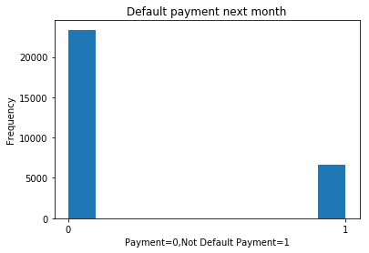

```python
data["default payment next month"].plot(kind="hist")
plt.xticks(range(0,2,1))
plt.xlabel("Payment=0,Not Default Payment=1")
plt.title("Default payment next month")
plt.show()
```

```python
data["default payment next month"].value_counts(normalize=True)
```

```
0    0.7788
1    0.2212
Name: default payment next month, dtype: float64
```

- 22.12% card holder are default payment and 77.88% card horlder without default payment.

**Credit Card limitation distribution**

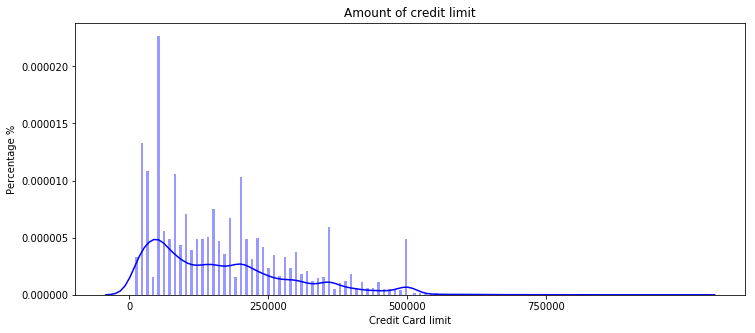

```python
plt.figure(figsize = (12,5))
plt.title('Amount of credit limit')
sns.distplot(data['LIMIT_BAL'],kde=True,bins=200, color="blue")
plt.xticks(range(0,1000000,250000))
plt.ylabel('Percentage %')
plt.xlabel('Credit Card limit')
plt.show()
```

```python
data["LIMIT_BAL"].value_counts().head(2)
```

[output not shown]

- From the plot shows that largest group with credit card limit is 50K group and second largest group of clients with credit card limit is 20K group.
- The credit card limit is a right tail distribution.

Now,we want to see is there a difference between people who is creaditable or not.

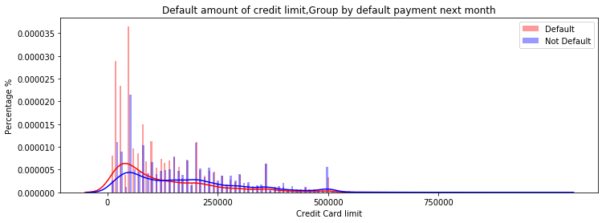

```python
class_0 = data.loc[data['default payment next month'] == 0]["LIMIT_BAL"]
class_1 = data.loc[data['default payment next month'] == 1]["LIMIT_BAL"]
plt.figure(figsize = (12,4))
sns.distplot(class_1,kde=True,bins=200, color="red")
sns.distplot(class_0,kde=True,bins=200, color="blue")
plt.title("Default amount of credit limit,Group by default payment next month")
plt.legend(["Default","Not Default"])
plt.xticks(range(0,1000000,250000))
plt.ylabel('Percentage %')
plt.xlabel('Credit Card limit')
plt.show()
```

Most of not creditable people have credit card limit around 20K to 50K. The clients without default payment have higher limit than people who with default payment.

**Gender**

Secondly, we want to see it there have a gender discrimination with credit card limit.

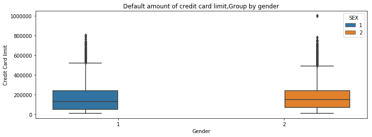

```python
plt.figure(figsize=(12,4))
sns.boxplot(x="SEX",y="LIMIT_BAL",data=data,hue="SEX")
plt.ylabel('Credit Card limit')
plt.xlabel("Gender")
plt.title("Default amount of credit card limit,Group by gender")
plt.show()
```

- The plot shows that male and female have similar credit card limit, so that gender may not be a great variables to use in classification.
- Female has a outler, but we think it is acceptable since maybe she is a CEO of some company and she has enough credit to loan more.

**Correlation**

Check the if there are linear relationships between features

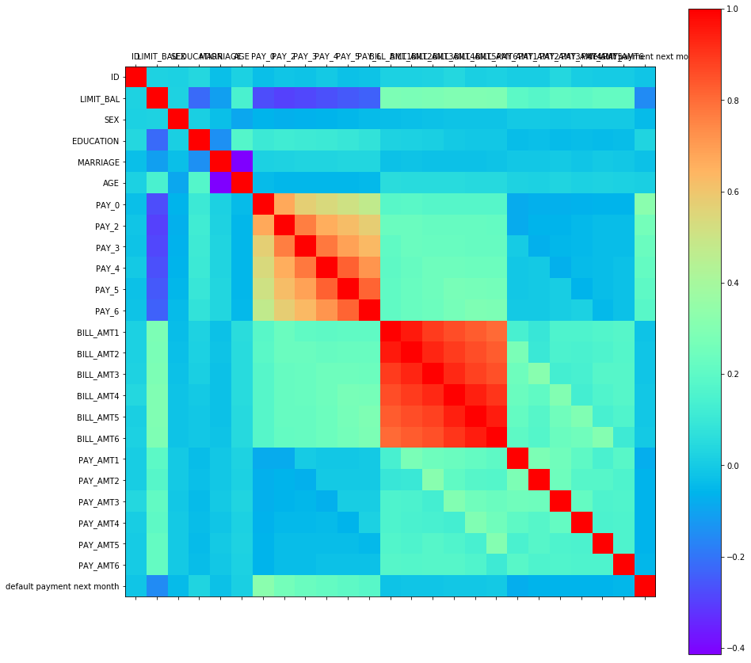

```python
def plot_corr(df,size=15):
    corr = df.corr()
    fig, ax = plt.subplots(figsize=(size, size))
    cax = ax.matshow(corr,cmap=plt.get_cmap('rainbow'))
    plt.xticks(range(len(corr.columns)), corr.columns)
    plt.yticks(range(len(corr.columns)), corr.columns)
    plt.colorbar(cax)
plot_corr(data)
```

- There are two main part of correlation, one is PAY variables and Bill variables.
- Corrlation of payment status is decreasing by times go on. From current month to past month or next month have highest correlation. The lowest correlation is between September and April.
- Also, corrlation of bill is decreasing by times go on. From current month to past month or next month have highest correlation. And the lowest correlation is between September and April.

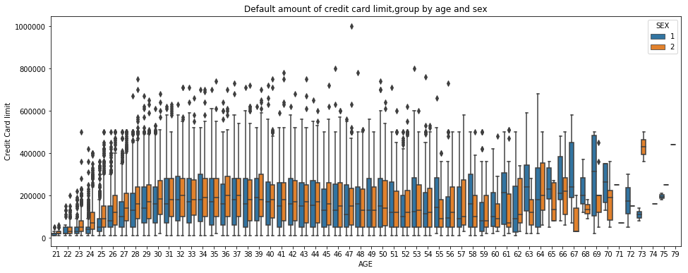

```python
fig, ax1 = plt.subplots(ncols=1, figsize=(16,6))
sns.boxplot(ax=ax1, x="AGE", y="LIMIT_BAL", data=data,hue='SEX')
plt.ylabel('Credit Card limit')
plt.xlabel("AGE")
plt.title("Default amount of credit card limit,group by age and sex")
plt.show()
```

**Marriage**

We may thinking about the marriage is a main factor to effect a person who with/without default payment.

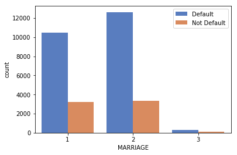

```python
sns.countplot(x="MARRIAGE", data=data,hue="default payment next month", palette="muted")
plt.legend(["Default","Not Default"])
```

MARRIAGE: Marital status (1 = married; 2 = single; 3 = others).

**Education vs. Default**

We want to check is there education level affect a clients with default payment or not.

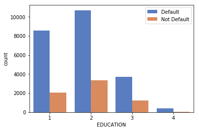

```python
sns.countplot(x="EDUCATION", data=data,hue="default payment next month", palette="muted")
plt.legend(["Default","Not Default"])
```

EDUCATION: Education (1 = graduate school; 2 = university; 3 = high school; 4 = others).

- EDUCATION Seems not affect too much to a client default payment or not.

**Payment**

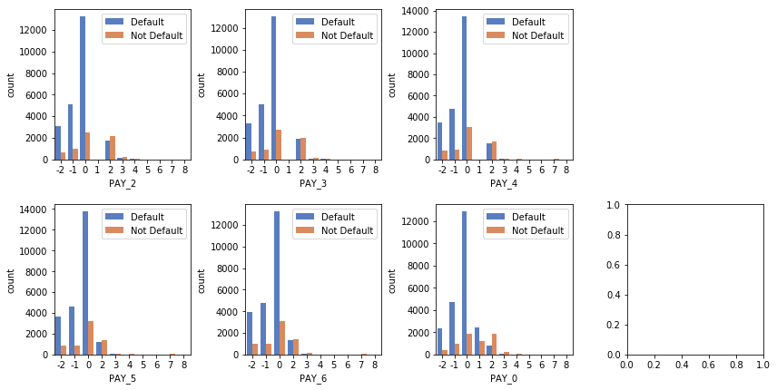

```python
plt.figure(figsize = (14,7))
grid = plt.GridSpec(2, 4, wspace=0.4, hspace=0.3)
sns.countplot(x="PAY_0", data=data,hue="default payment next month", palette="muted")
plt.legend(["Default","Not Default"])
plt.subplot(grid[0,0])
sns.countplot(x="PAY_2", data=data,hue="default payment next month", palette="muted")
plt.legend(["Default","Not Default"])
plt.subplot(grid[0,1])
sns.countplot(x="PAY_3", data=data,hue="default payment next month", palette="muted")
plt.legend(["Default","Not Default"])
plt.subplot(grid[0,2])
sns.countplot(x="PAY_4", data=data,hue="default payment next month", palette="muted")
plt.legend(["Default","Not Default"])
plt.subplot(grid[1,0])
sns.countplot(x="PAY_5", data=data,hue="default payment next month", palette="muted")
plt.legend(["Default","Not Default"])
plt.subplot(grid[1,1])
sns.countplot(x="PAY_6", data=data,hue="default payment next month", palette="muted")
plt.legend(["Default","Not Default"])
plt.subplot(grid[1,2])
sns.countplot(x="PAY_0", data=data,hue="default payment next month", palette="muted")
plt.legend(["Default","Not Default"])
plt.subplot(grid[1,3])
plt.show()
```

**Data Modeling**

```python
#split the train data and test data
random.seed(777)
train_data = data.sample(frac=5/6, replace=False)
test_data = data.sample(frac=1/6, replace=False)
print (train_data.shape)
print (test_data.shape)
```

```
(25000, 25)
(5000, 25)
```

```python
y_train = train_data['default payment next month']
y_test=test_data['default payment next month']
x_train = train_data.drop(['default payment next month', 'ID'], axis= 1)
x_test = test_data.drop(['default payment next month', 'ID'], axis= 1)
print (y_train.shape)
print (y_test.shape)
print (x_train.shape)
print (x_test.shape)
```

```
(25000,)
(5000,)
(25000, 23)
(5000, 23)
```

**Random Forest：**

We used random forest tree model as our first baseline model since:

1. Random Forest is a flexible algorithm that uses several tree models to split the data into two groups based on one of the predictors repeatedly until several groups are formed.
2. Random Forest is a very effective classification method, when dealing with a mixture of several numerical and categorical variables.
3. By principle since it randomizes the variable selection during each tree split it's not prone to overfit unlike other models. Also,We don't need to pre-precessing data too much.

```python
from sklearn.ensemble import RandomForestClassifier
RF = RandomForestClassifier(class_weight = {0:1, 1:3})
RF.fit(x_train, y_train)
y_pred = RF.predict(x_test)
acc_RF = round(accuracy_score(y_test,y_pred) * 100, 2)
print(RF.score(x_train, y_train))
print (acc_RF,"%")
```

```
0.97856
95.12 %
```

We can see the score is not too far away from the test predition, so it's not overfiting.

We use the Grid search cross validation to fine-tune the parameter for random forester model, which also can help use prevent the model overfitting.

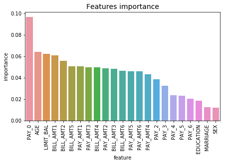

```python
features = pd.DataFrame()
features['feature'] = x_train.columns
features['importance'] = RF.feature_importances_
features = features.sort_values(by='importance',ascending=False)
plt.figure(figsize = (7,4))
plt.title('Features importance',fontsize=14)
s = sns.barplot(x='feature',y='importance',data=features)
s.set_xticklabels(s.get_xticklabels(),rotation=90)
plt.show()
```

```python
from sklearn.model_selection import GridSearchCV
from sklearn.model_selection import cross_val_score
def search_model(x_train, y_train, est, param_grid, n_jobs, cv):
    model = GridSearchCV(estimator  = est,
                                     param_grid = param_grid,
                                     scoring = 'f1_weighted',
                                     verbose = 10,
                                     n_jobs = n_jobs,
                                     iid = True,
                                     cv = cv)
    # Fit Grid Search Model
    model.fit(x_train, y_train)
    return model
```

Grid search is actually using cross validation method to tune parameters, which is to scan all posible parameter combinations and return the best one.

```python
param_grid = {'n_estimators':[100,300,500],
             'criterion':['gini', 'entropy'],
             'class_weight': [{0:1, 1:3}]}

RF = search_model(x_train, y_train
            , RandomForestClassifier()
            , param_grid
            , -1
            , 5)
RF.fit(x_train, y_train)
y_pred = RF.predict(x_test)
acc_RF = round(accuracy_score(y_test,y_pred) * 100, 2)
print(RF.score(x_train, y_train))
print (acc_RF,"%")
```

```
Fitting 5 folds for each of 6 candidates, totalling 30 fits
```

[output not shown]

```
Fitting 5 folds for each of 6 candidates, totalling 30 fits
```

[output not shown]

```
0.9992005110117503
96.9
```

After tune the parameters, the predicting accuracy reach up to 96.9%, and the model score accuracy reach up to 99.92%.

**Logistic regression**

- Like all regression analyses, the logistic regression is a predictive analysis. Logistic regression is used to describe data and to explain the relationship between one dependent binary variable and one or more nominal, ordinal, interval or ratio-level independent variables.
- We can use it to determin our binary results ('default payment next month') in this dataset.

```python
from sklearn.linear_model import LogisticRegression
model = LogisticRegression()
model.fit(x_train, y_train)
y_pred_log = model.predict(x_test)
acc_log = round(accuracy_score(y_test,y_pred_log) * 100, 2)
print (acc_log,"%")
```

```
76.44 %
```

**LogisticCV regression**

```python
from sklearn.linear_model import LogisticRegressionCV
model = LogisticRegressionCV()
model.fit(x_train, y_train)
y_pred_logcv = model.predict(x_test)
acc_logcv = round(accuracy_score(y_test,y_pred_logcv) * 100, 2)
print (acc_logcv,"%")
```

```
76.44 %
```

**Support vector machine(SVM)**

- Support vector machines is supervised learning models with associated learning algorithms that analyze data used for classification analysis. Given a set of training examples, each marked as belonging to one or the other of two categories, an SVM training algorithm builds a model that assigns new examples to one category or the other.

```python
from sklearn.svm import SVC
model = SVC()
model.fit(x_train, y_train)
y_pred_svc = model.predict(x_test)
acc_svc = round(accuracy_score(y_test,y_pred_svc) * 100, 2)
print (acc_svc,"%")
```

```
95.32
```

**Linear SVM**

- Linear Support Vector Classification is similar to SVM with parameter kernel=’linear’, but implemented in terms of liblinear rather than libsvm, so it has more flexibility in the choice of penalties and loss functions and should scale better to large numbers of samples.

```python
from sklearn.svm import LinearSVC
model = LinearSVC()
model.fit(x_train, y_train)
y_pred_lsvc = model.predict(x_test)
acc_lsvc = round(accuracy_score(y_test,y_pred_lsvc) * 100, 2)
print (acc_lsvc,"%")
```

```
74.54 %
```

**K-nearest neighbors algorithm(KNN)**

- In k-NN classification, the output is a class membership. An object is classified by a majority vote of its neighbors, with the object being assigned to the class most common among its k nearest neighbors. KNN function is only approximated locally and all computation is deferred until classification.

```python
from sklearn.neighbors import KNeighborsClassifier
model = KNeighborsClassifier(n_neighbors = 3)
model.fit(x_train, y_train)
y_pred_knn = model.predict(x_test)
acc_knn = round(accuracy_score(y_test,y_pred_knn) * 100, 2)
print (acc_knn,"%")
```

```
81.14 %
```

**Decision Tree**

- A decision tree is a decision support tool that uses a tree-like model of decisions and their possible consequences, including chance event outcomes, resource costs, and utility. A decision tree is a flowchart-like structure in which each internal node represents a "test" on an attribute, each branch represents the outcome of the test, and each leaf node represents a class label. It's more like the random forest but only use one tree to classifier the data.

```python
from sklearn.tree import DecisionTreeClassifier
model = DecisionTreeClassifier()
model.fit(x_train, y_train)
y_pred_DT = model.predict(x_test)
acc_DT = round(accuracy_score(y_test,y_pred_DT) * 100, 2)
print (acc_DT,"%")
```

```
95.58 %
```

**Gaussian Naive Bayes**

- Naive Bayes is a simple technique for constructing classifiers: models that assign class labels to problem instances, represented as vectors of feature values, where the class labels are drawn from some finite set. There is not a single algorithm for training such classifiers, but a family of algorithms based on a common principle: all naive Bayes classifiers assume that the value of a particular feature is independent of the value of any other feature, given the class variable.

```python
from sklearn.naive_bayes import GaussianNB
model = GaussianNB()
model.fit(x_train, y_train)
y_pred_GNB = model.predict(x_test)
acc_GNB = round(accuracy_score(y_test,y_pred_GNB) * 100, 2)
print (acc_GNB,"%")
```

```
38.34 %
```

**Accuracy Summary**

```python
acc = pd.DataFrame()
acc['Accuracy(%)'] = [acc_RF,acc_log,acc_logcv,acc_svc,acc_lsvc,acc_knn,acc_DT,acc_GNB]
acc['Method']=['Random Forest','Logistic','LogisticCV',"SVM",
               "Linear SVM","KNN","Decision Tree",'Gaussian Naive Bayes']
acc.index=acc.Method
acc = acc.sort_values(by='Accuracy(%)',ascending=False)
print(acc.drop(['Method'],axis=1))
```

[output not shown]

[figure not shown]

```python
plt.figure(figsize = (7,4))
plt.title('Accuracy',fontsize=14)
s = sns.barplot(x='Method',y='Accuracy(%)',data=acc)
s.set_xticklabels(s.get_xticklabels(),rotation=90)
plt.show()
```

**After comparing all the models, we can see the random forest is the best predicting model for this dataset.**